# Graded_Project_Code

## La Liga Data Analysis using Python

#### Importing required libraries.

```python
import numpy as np
import pandas as pd

import matplotlib.pyplot as plt
%matplotlib inline

import warnings
```

#### Suppressing warning display.

```python
warnings.filterwarnings('ignore')
```

#### Setting dataset display options.

```python
pd.options.display.max_columns=None
pd.options.display.max_rows=None
pd.options.display.float_format = '{:.4f}'.format
```

### Question 1

#### Importing dataset and displaying top rows.

```python
df = pd.read_csv('Laliga_scores.csv', skiprows=1) # skipping first row since it is empty
df.head(7)
```

|  | Pos | Team | Seasons | Points | GamesPlayed | GamesWon | GamesDrawn | GamesLost | GoalsFor | GoalsAgainst | Champion | Runner-up | Third | Fourth | Fifth | Sixth | Debut | BestPosition |
| --- | --- | --- | --- | --- | --- | --- | --- | --- | --- | --- | --- | --- | --- | --- | --- | --- | --- | --- |
| 0 | 1 | Real Madrid | 86 | 4385 | 2762 | 1647 | 552 | 563 | 5947 | 3140 | 33 | 23 | 8 | 8 | 3 | 4 | 1929 | 1 |
| 1 | 2 | Barcelona | 86 | 4262 | 2762 | 1581 | 573 | 608 | 5900 | 3114 | 25 | 25 | 12 | 12 | 4 | 6 | 1929 | 1 |
| 2 | 3 | Atletico Madrid | 80 | 3442 | 2614 | 1241 | 598 | 775 | 4534 | 3309 | 10 | 8 | 16 | 9 | 7 | 6 | 1929 | 1 |
| 3 | 4 | Valencia | 82 | 3386 | 2664 | 1187 | 616 | 861 | 4398 | 3469 | 6 | 6 | 10 | 11 | 10 | 7 | 1931-32 | 1 |
| 4 | 5 | Athletic Bilbao | 86 | 3368 | 2762 | 1209 | 633 | 920 | 4631 | 3700 | 8 | 7 | 10 | 5 | 8 | 10 | 1929 | 1 |
| 5 | 6 | Sevilla | 73 | 2819 | 2408 | 990 | 531 | 887 | 3680 | 3373 | 1 | 4 | 4 | 5 | 12 | 6 | 1934-35 | 1 |
| 6 | 7 | Espanyol | 82 | 2792 | 2626 | 948 | 608 | 1070 | 3609 | 3889 | - | - | 4 | 5 | 2 | 5 | 1929 | 3 |

#### General information about the dataset.

```python
df.info()
```

```
<class 'pandas.core.frame.DataFrame'>
RangeIndex: 61 entries, 0 to 60
Data columns (total 18 columns):
 #   Column        Non-Null Count  Dtype
---  ------        --------------  -----
 0   Pos           61 non-null     int64
 1   Team          61 non-null     object
 2   Seasons       61 non-null     int64
 3   Points        61 non-null     object
 4   GamesPlayed   61 non-null     object
 5   GamesWon      61 non-null     object
 6   GamesDrawn    61 non-null     object
 7   GamesLost     61 non-null     object
 8   GoalsFor      61 non-null     object
 9   GoalsAgainst  61 non-null     object
 10  Champion      61 non-null     object
 11  Runner-up     61 non-null     object
 12  Third         61 non-null     object
 13  Fourth        61 non-null     object
 14  Fifth         61 non-null     object
 15  Sixth         61 non-null     object
 16  Debut         61 non-null     object
 17  BestPosition  61 non-null     int64
dtypes: int64(3), object(15)
memory usage: 8.7+ KB
```

There are 18 columns in total.

Since the dataset has 61 entries and all columns have 61 non-Null values we can say that there are no null values.

#### Replacing '-' values with 0s to enable arithmatic calculations.

```python
df.replace({'-': 0},inplace =True)
```

#### Dataset after replacing '-' values with 0s

```python
df.head(7)
```

|  | Pos | Team | Seasons | Points | GamesPlayed | GamesWon | GamesDrawn | GamesLost | GoalsFor | GoalsAgainst | Champion | Runner-up | Third | Fourth | Fifth | Sixth | Debut | BestPosition |
| --- | --- | --- | --- | --- | --- | --- | --- | --- | --- | --- | --- | --- | --- | --- | --- | --- | --- | --- |
| 0 | 1 | Real Madrid | 86 | 4385 | 2762 | 1647 | 552 | 563 | 5947 | 3140 | 33 | 23 | 8 | 8 | 3 | 4 | 1929 | 1 |
| 1 | 2 | Barcelona | 86 | 4262 | 2762 | 1581 | 573 | 608 | 5900 | 3114 | 25 | 25 | 12 | 12 | 4 | 6 | 1929 | 1 |
| 2 | 3 | Atletico Madrid | 80 | 3442 | 2614 | 1241 | 598 | 775 | 4534 | 3309 | 10 | 8 | 16 | 9 | 7 | 6 | 1929 | 1 |
| 3 | 4 | Valencia | 82 | 3386 | 2664 | 1187 | 616 | 861 | 4398 | 3469 | 6 | 6 | 10 | 11 | 10 | 7 | 1931-32 | 1 |
| 4 | 5 | Athletic Bilbao | 86 | 3368 | 2762 | 1209 | 633 | 920 | 4631 | 3700 | 8 | 7 | 10 | 5 | 8 | 10 | 1929 | 1 |
| 5 | 6 | Sevilla | 73 | 2819 | 2408 | 990 | 531 | 887 | 3680 | 3373 | 1 | 4 | 4 | 5 | 12 | 6 | 1934-35 | 1 |
| 6 | 7 | Espanyol | 82 | 2792 | 2626 | 948 | 608 | 1070 | 3609 | 3889 | 0 | 0 | 4 | 5 | 2 | 5 | 1929 | 3 |

#### Converting all columns except Team and Debut(since it has composite values) to integer type.

```python
column_type = {'Pos':int, 'Seasons':int, 'Points':int, 'GamesPlayed':int, 'GamesWon':int, 'GamesDrawn':int, 'GamesLost':int,
               'GoalsFor':int, 'GoalsAgainst':int, 'Champion':int, 'Runner-up':int, 'Third':int, 'Fourth':int, 'Fifth':int,
               'Sixth':int, 'BestPosition':int,}
df = df.astype(column_type)
```

#### After changing column datatypes

```python
df.info()
```

```
<class 'pandas.core.frame.DataFrame'>
RangeIndex: 61 entries, 0 to 60
Data columns (total 18 columns):
 #   Column        Non-Null Count  Dtype
---  ------        --------------  -----
 0   Pos           61 non-null     int32
 1   Team          61 non-null     object
 2   Seasons       61 non-null     int32
 3   Points        61 non-null     int32
 4   GamesPlayed   61 non-null     int32
 5   GamesWon      61 non-null     int32
 6   GamesDrawn    61 non-null     int32
 7   GamesLost     61 non-null     int32
 8   GoalsFor      61 non-null     int32
 9   GoalsAgainst  61 non-null     int32
 10  Champion      61 non-null     int32
 11  Runner-up     61 non-null     int32
 12  Third         61 non-null     int32
 13  Fourth        61 non-null     int32
 14  Fifth         61 non-null     int32
 15  Sixth         61 non-null     int32
 16  Debut         61 non-null     object
 17  BestPosition  61 non-null     int32
dtypes: int32(16), object(2)
memory usage: 4.9+ KB
```

#### Distribution for the best position.

```python
best_position_counts = df.BestPosition.value_counts()
print(best_position_counts)
```

```
1     9
4     6
7     5
2     5
6     5
3     4
5     4
10    4
8     4
17    3
16    3
9     2
12    2
19    1
11    1
14    1
15    1
20    1
Name: BestPosition, dtype: int64
```

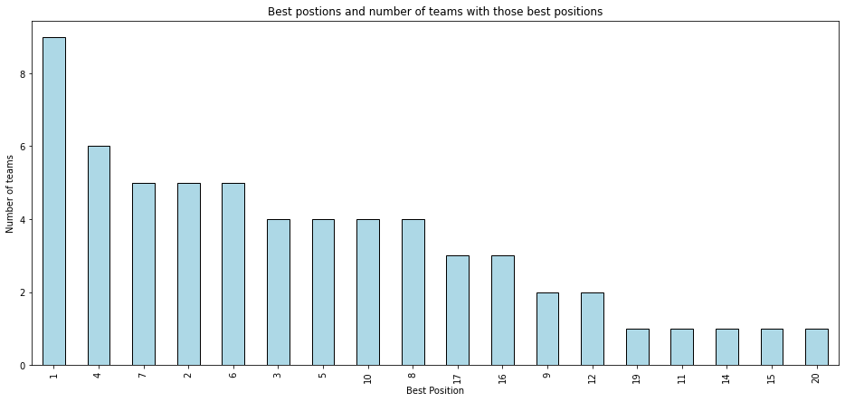

```python
best_position_counts.plot(kind='bar', edgecolor='black', color='lightblue', figsize=(16,7))
plt.ylabel('Number of teams')
plt.xlabel('Best Position')
plt.title('Best postions and number of teams with those best positions')
plt.show()
```

```python
print('Top best position :')
print(best_position_counts.index[0])
```

```
Top best position :
1
```

We can clearly observe that position 1 is the top best position in terms of number of teams who have it as their best position, total 9 teams have position 1 as their best position.

### Question 2

#### Printing all team names which have started playing between 1930-1980, including 1930 only (as asked in the question).

#### Converting composite values of the form '1931-32' in the Debut column to single year (integer) values of the form 1931.

```python
def get_single_debut_year(debut):
    return int(debut.split(sep='-')[0])
```

```python
df['Debut_1'] = df['Debut'].apply(get_single_debut_year)
```

```python
df.head()
```

|  | Pos | Team | Seasons | Points | GamesPlayed | GamesWon | GamesDrawn | GamesLost | GoalsFor | GoalsAgainst | Champion | Runner-up | Third | Fourth | Fifth | Sixth | Debut | BestPosition | Debut_1 |
| --- | --- | --- | --- | --- | --- | --- | --- | --- | --- | --- | --- | --- | --- | --- | --- | --- | --- | --- | --- |
| 0 | 1 | Real Madrid | 86 | 4385 | 2762 | 1647 | 552 | 563 | 5947 | 3140 | 33 | 23 | 8 | 8 | 3 | 4 | 1929 | 1 | 1929 |
| 1 | 2 | Barcelona | 86 | 4262 | 2762 | 1581 | 573 | 608 | 5900 | 3114 | 25 | 25 | 12 | 12 | 4 | 6 | 1929 | 1 | 1929 |
| 2 | 3 | Atletico Madrid | 80 | 3442 | 2614 | 1241 | 598 | 775 | 4534 | 3309 | 10 | 8 | 16 | 9 | 7 | 6 | 1929 | 1 | 1929 |
| 3 | 4 | Valencia | 82 | 3386 | 2664 | 1187 | 616 | 861 | 4398 | 3469 | 6 | 6 | 10 | 11 | 10 | 7 | 1931-32 | 1 | 1931 |
| 4 | 5 | Athletic Bilbao | 86 | 3368 | 2762 | 1209 | 633 | 920 | 4631 | 3700 | 8 | 7 | 10 | 5 | 8 | 10 | 1929 | 1 | 1929 |

```python
print('Teams which debuted between 1930 (included) and 1980 (excluded): \n')
print(df[(df.Debut_1>=1930) & (df.Debut_1<1980)][['Team', 'Debut']].to_string(index=False))
```

```
Teams which debuted between 1930 (included) and 1980 (excluded):

                Team    Debut
            Valencia  1931-32
             Sevilla  1934-35
            Zaragoza  1939-40
          Real Betis  1932-33
 Deportivo La Coruna  1941-42
          Celta Vigo  1939-40
          Valladolid  1948-49
      Sporting Gijon  1944-45
             Osasuna  1935-36
              Malaga  1949-50
              Oviedo  1933-34
            Mallorca  1960-61
          Las Palmas  1951-52
             Granada  1941-42
      Rayo Vallecano  1977-78
               Elche  1959-60
            Hercules  1935-36
            Tenerife  1961-62
              Murcia  1940-41
              Alaves  1930-31
             Levante  1963-64
           Salamanca  1974-75
            Sabadell  1943-44
               Cadiz  1977-78
           Castellon  1941-42
             Cordoba  1962-63
          Recreativo  1978-79
           Burgos CF  1971-72
          Pontevedra  1963-64
           Gimnastic  1947-48
            Alcoyano  1945-46
                Jaen  1953-54
          AD Almeria  1979-80
              Lleida  1950-51
              Condal  1956-57
     Atletico Tetuan  1951-52
    Cultural Leonesa  1955-56
```

### Question 3

#### Printing list of top 5 teams by points.

```python
print('List of top 5 teams by ponits: \n')
print(df.nlargest(5,'Points')[['Team', 'Points']].to_string(index=False))
```

```
List of top 5 teams by ponits:

            Team  Points
     Real Madrid    4385
       Barcelona    4262
 Atletico Madrid    3442
        Valencia    3386
 Athletic Bilbao    3368
```

### Question 4

#### Teams and their goal differences.

```python
def Goal_diff_count(df_temp):
    df_temp['Goal Difference Count'] = df.GoalsFor-df.GoalsAgainst
    return df_temp[['Team', 'Goal Difference Count']]
```

```python
print('Teams and their goal differences: \n')
print(Goal_diff_count(df).to_string(index=False))
```

```
Teams and their goal differences:

                Team  Goal Difference Count
         Real Madrid                   2807
           Barcelona                   2786
     Atletico Madrid                   1225
            Valencia                    929
     Athletic Bilbao                    931
             Sevilla                    307
            Espanyol                   -280
       Real Sociedad                     -2
            Zaragoza                   -164
          Real Betis                   -333
 Deportivo La Coruna                   -136
          Celta Vigo                   -346
          Valladolid                   -413
    Racing Santander                   -525
      Sporting Gijon                   -399
             Osasuna                   -334
              Malaga                   -342
              Oviedo                   -309
            Mallorca                   -189
          Las Palmas                   -399
          Villarreal                    103
             Granada                   -338
      Rayo Vallecano                   -328
               Elche                   -272
              Getafe                   -113
            Hercules                   -334
            Tenerife                   -125
              Murcia                   -385
              Alaves                   -165
             Levante                   -202
           Salamanca                   -159
            Sabadell                   -228
               Cadiz                   -269
            Logrones                   -198
           Castellon                   -169
            Albacete                    -90
             Almeria                   -122
```

[output cut: 9 more lines]

```
           Gimnastic                   -114
         Extremadura                    -55
              Merida                    -45
            Alcoyano                   -107
                Jaen                    -62
          Real Union                    -31
          AD Almeria                    -45
              Europa                    -34
              Lleida                   -112
             Leganes                    -19
               Xerez                    -28
              Condal                    -20
     Atletico Tetuan                    -34
    Cultural Leonesa                    -31
              Girona                      0
```

### Question 5

#### Finding teams with maximum and minimum goal differences.

```python
goal_diff_count_df = Goal_diff_count(df)
max_goal_diff_count_team = goal_diff_count_df[goal_diff_count_df['Goal Difference Count']==max(goal_diff_count_df['Goal Difference Count'])][['Team', 'Goal Difference Count']].values[0]
min_goal_diff_count_team = goal_diff_count_df[goal_diff_count_df['Goal Difference Count']==min(goal_diff_count_df['Goal Difference Count'])][['Team', 'Goal Difference Count']].values[0]

print('Team with maximum goal difference count is',max_goal_diff_count_team[0],'with goal difference of',max_goal_diff_count_team[1])
print('Team with minimum goal difference count is',min_goal_diff_count_team[0],'with goal difference of',min_goal_diff_count_team[1])
```

```
Team with maximum goal difference count is Real Madrid with goal difference of 2807
Team with minimum goal difference count is Racing Santander with goal difference of -525
```

### Question 6

#### Creating a new 'Winning Percent" column, and replacing values with numerical error (NaN values) to 0%.

```python
df['Winning Percent'] = 100*df['GamesWon']/df['GamesPlayed']
df['Winning Percent'] = df['Winning Percent'].fillna(0)

print('Teams and their winning percentages: \n')
print(df[['Team', 'Winning Percent']].to_string(index=False))
```

```
Teams and their winning percentages:

                Team  Winning Percent
         Real Madrid          59.6307
           Barcelona          57.2411
     Atletico Madrid          47.4751
            Valencia          44.5571
     Athletic Bilbao          43.7726
             Sevilla          41.1130
            Espanyol          36.1005
       Real Sociedad          37.5326
            Zaragoza          35.1460
          Real Betis          35.0694
 Deportivo La Coruna          36.7974
          Celta Vigo          34.5112
          Valladolid          31.5825
    Racing Santander          31.7227
      Sporting Gijon          32.3045
             Osasuna          32.3217
              Malaga          31.0757
              Oviedo          34.2282
            Mallorca          33.7045
          Las Palmas          33.4854
          Villarreal          41.1765
             Granada          29.3801
      Rayo Vallecano          28.9877
               Elche          29.9410
              Getafe          32.2368
            Hercules          29.2994
            Tenerife          31.3765
              Murcia          24.7440
              Alaves          32.8947
             Levante          28.1095
           Salamanca          29.0780
            Sabadell          30.2817
               Cadiz          23.2143
            Logrones          27.7457
           Castellon          30.8383
            Albacete          28.1481
             Almeria          27.1930
```

[output cut: 9 more lines]

```
           Gimnastic          29.3103
         Extremadura          25.0000
              Merida          23.7500
            Alcoyano          27.7778
                Jaen          32.2222
          Real Union          29.1667
          AD Almeria          25.0000
              Europa          33.3333
              Lleida          19.1176
             Leganes          21.0526
               Xerez          21.0526
              Condal          23.3333
     Atletico Tetuan          23.3333
    Cultural Leonesa          16.6667
              Girona           0.0000
```

### Question 7

#### Printing top 5 teams by winning percentage

```python
print('Top 5 teams by winning percentage: \n')
print(df.nlargest(5, "Winning Percent")[['Team', 'Winning Percent']].to_string(index=False))
```

```
Top 5 teams by winning percentage:

            Team  Winning Percent
     Real Madrid          59.6307
       Barcelona          57.2411
 Atletico Madrid          47.4751
        Valencia          44.5571
 Athletic Bilbao          43.7726
```

### Question 8

#### Grouping teams based on their best position and printing sum of points for all best positions

```python
print('Best positions and sum of points of all teams in the respective best positions: \n')
print(df[["BestPosition", "Points"]].groupby('BestPosition').sum())
```

```
Best positions and sum of points of all teams in the respective best positions:

              Points
BestPosition
1              27933
2               6904
3               5221
4               6563
5               1884
6               2113
7               1186
8               1134
9                 96
10               450
11               445
12               511
14                71
15                14
16                81
17               266
19                81
20                34
```